# homework-05

Brian J Lesko

2022-06-09

```r
 library(tidyverse)
library(nycflights13)
```

# Reading: R4DS 5.6-5.7

## Reading notes

### 5.6

group_by() & summarise() can let you apply things by group? instead of naming each transformation step, a pipe can be used %>% the pipe operation %>% can be read as a then statement usually you want to remove NA’s with the argument na.rm =TRUE

# R4DS Exercises

## 5.6.7 (1-6)

Hints: + for exercise 4, plot x=day and facet by month. Think about weather + Try a scatterplot for part 2, experiment with log scales

### Exercise 1

brainstorm 5+ ways to assess the typical delay characteristics of a group of flights. Consider these scenarios + a flight is 15 min early 50% of the time and 15 min late 50% of the time This will result in an average of no delay, which is misleading. + a flight is always 10 minutes late + same scenario as the first but 30 minutes late/early this time + 99% on time 1% of the time the flight is delayed.

*5 Ways to assess delay characteristics:* group flights by airport, then analyze

1. obtain descriptive statistics: a measure of Central tendancy(like mean), Dispersion (like standard deviation) of delay can be done for arrival delay and departure delay These are characteristics of delay by grouped flights
2. Plot delays to visualize them 2.1 Facet by airline or other categorical variables characterize delay by airline 2.2 (3) plot mean delays of groups vs average flight duration Can also facet by airline this characterises delay by flight duration 2.3 (4) use aesthetics to get an overview can test out the relationship between arrival and departure delay
3. Range can be useful due to early arrivals being marked as negative delays.
4. Alternative to using range, early arrivals can be filtered out to only characterize delayed flights.
5. delays can also affect following flights.
6. degree of skew and kurtosis can also be important

What is more important? arrival or departure delay? arrival delay because time can be recouped after a late departure, but not after arrival, which makes this stat more important.

### Exercise 2

characterize delay such that the output is the same as the following code block but do not use the count() function

```r
# we need the code written previously in the chapter in order to have the objects refrenced within this exercise. Below are the required lines

#removing NA's is removing cancelled flights in this dataset (established previously)
not_cancelled <- flights %>%
  filter(!is.na(dep_delay),!is.na(arr_delay))

#grouping the data by year month and day
not_cancelled %>%
  group_by(year,month,day) %>%
  summarise(mean = mean(dep_delay)) #now the dataset consists of one row per day with the mean values for dep_delay instead of one row per flight.
```

```
## # A tibble: 365 × 4
## # Groups:   year, month [12]
##     year month   day  mean
##    <int> <int> <int> <dbl>
##  1  2013     1     1 11.4
##  2  2013     1     2 13.7
##  3  2013     1     3 10.9
##  4  2013     1     4  8.97
##  5  2013     1     5  5.73
##  6  2013     1     6  7.15
##  7  2013     1     7  5.42
##  8  2013     1     8  2.56
##  9  2013     1     9  2.30
## 10  2013     1    10  2.84
## # … with 355 more rows
```

```r
library(tidyverse)
library("nycflights13")

# the useage of counting is good to make sure conclusions are not based on small datasets
not_cancelled %>% count(dest) # this counts number of flights out of each airport
```

```
## # A tibble: 104 × 2
##    dest      n
##    <chr> <int>
##  1 ABQ     254
##  2 ACK     264
##  3 ALB     418
##  4 ANC       8
##  5 ATL   16837
##  6 AUS    2411
##  7 AVL     261
##  8 BDL     412
##  9 BGR     358
## 10 BHM     269
## # … with 94 more rows
```

```r
not_cancelled %>% count(tailnum, wt=distance) #this counts flights per plane in the dataset
```

```
## # A tibble: 4,037 × 2
##    tailnum      n
##    <chr>    <dbl>
##  1 D942DN    3418
##  2 N0EGMQ  239143
##  3 N10156  109664
##  4 N102UW   25722
##  5 N103US   24619
##  6 N104UW   24616
##  7 N10575  139903
##  8 N105UW   23618
##  9 N107US   21677
## 10 N108UW   32070
## # … with 4,027 more rows
```

```r
#This shows that count() groups and then summarises such that the outputs are roughly equivelenat
not_cancelled %>% group_by(dest) %>% summarise(n=n())
```

```
## # A tibble: 104 × 2
##    dest      n
##    <chr> <int>
##  1 ABQ     254
##  2 ACK     264
##  3 ALB     418
##  4 ANC       8
##  5 ATL   16837
##  6 AUS    2411
##  7 AVL     261
##  8 BDL     412
##  9 BGR     358
## 10 BHM     269
## # … with 94 more rows
```

```r
not_cancelled %>% group_by(tailnum) %>% summarise(n=n())
```

```
## # A tibble: 4,037 × 2
##    tailnum     n
##    <chr>   <int>
##  1 D942DN      4
##  2 N0EGMQ    352
##  3 N10156    145
##  4 N102UW     48
##  5 N103US     46
##  6 N104UW     46
##  7 N10575    269
##  8 N105UW     45
##  9 N107US     41
## 10 N108UW     60
## # … with 4,027 more rows
```

```r
#Alternatively, the summarise argument can be changed to n=sum(!is.na()))
```

### Exercise 3

Our definition of cancelled flights (is.na(dep_delay) | is.na(arr_delay) ) is slightly suboptimal. Why? Which is the most important column?

Arrival delay is more imporant. when lookin at the data, there are flights that leave but do not arrive. These flights have a dep_delay but have NA as their arr_delay

this means that dep_delay being NA is irrelevant when looking for cancelled flights

```r
#to see the NA's
filter(flights, is.na(dep_delay))
```

```
## # A tibble: 8,255 × 19
##     year month   day dep_time sched_dep_time dep_delay arr_time sched_arr_time
##    <int> <int> <int>    <int>          <int>     <dbl>    <int>          <int>
##  1  2013     1     1       NA           1630        NA       NA           1815
##  2  2013     1     1       NA           1935        NA       NA           2240
##  3  2013     1     1       NA           1500        NA       NA           1825
##  4  2013     1     1       NA            600        NA       NA            901
##  5  2013     1     2       NA           1540        NA       NA           1747
##  6  2013     1     2       NA           1620        NA       NA           1746
##  7  2013     1     2       NA           1355        NA       NA           1459
##  8  2013     1     2       NA           1420        NA       NA           1644
##  9  2013     1     2       NA           1321        NA       NA           1536
## 10  2013     1     2       NA           1545        NA       NA           1910
## # … with 8,245 more rows, and 11 more variables: arr_delay <dbl>,
## #   carrier <chr>, flight <int>, tailnum <chr>, origin <chr>, dest <chr>,
## #   air_time <dbl>, distance <dbl>, hour <dbl>, minute <dbl>, time_hour <dttm>
```

```r
#It is seen that some cancelled flights do indeed havea  departure time where no cancelled flights have an arrival time. Therefor, the arrival time is more important
filter(flights, is.na(arr_delay))
```

```
## # A tibble: 9,430 × 19
##     year month   day dep_time sched_dep_time dep_delay arr_time sched_arr_time
##    <int> <int> <int>    <int>          <int>     <dbl>    <int>          <int>
##  1  2013     1     1     1525           1530        -5     1934           1805
##  2  2013     1     1     1528           1459        29     2002           1647
##  3  2013     1     1     1740           1745        -5     2158           2020
##  4  2013     1     1     1807           1738        29     2251           2103
##  5  2013     1     1     1939           1840        59       29           2151
##  6  2013     1     1     1952           1930        22     2358           2207
##  7  2013     1     1     2016           1930        46       NA           2220
##  8  2013     1     1       NA           1630        NA       NA           1815
##  9  2013     1     1       NA           1935        NA       NA           2240
## 10  2013     1     1       NA           1500        NA       NA           1825
## # … with 9,420 more rows, and 11 more variables: arr_delay <dbl>,
## #   carrier <chr>, flight <int>, tailnum <chr>, origin <chr>, dest <chr>,
## #   air_time <dbl>, distance <dbl>, hour <dbl>, minute <dbl>, time_hour <dttm>
```

### Exercise 4

Look at the number of cancelled flights per day. Is there a pattern? Is the proportion of cancelled flights related to the average delay?

```r
#Scratch work

#Finding the number of cancelled flights per day
cancelled_flights_per_day <- flights %>%
  filter(is.na(arr_time)) %>%
  group_by(year,month,day) %>%
  summarise(n=n())   #Instead of using group_by and summarise, counts() can be used

cancelled_flights_per_day
```

```
## # A tibble: 359 × 4
## # Groups:   year, month [12]
##     year month   day     n
##    <int> <int> <int> <int>
##  1  2013     1     1     5
##  2  2013     1     2    10
##  3  2013     1     3    10
##  4  2013     1     4     6
##  5  2013     1     5     3
##  6  2013     1     6     1
##  7  2013     1     7     3
##  8  2013     1     8     4
##  9  2013     1     9     7
## 10  2013     1    10     3
## # … with 349 more rows
```

```r
#Finding the average delay per day
avg_delay <- not_cancelled %>% group_by(year,month,day) %>% summarise(mean=mean(arr_delay))
avg_delay
```

```
## # A tibble: 365 × 4
## # Groups:   year, month [12]
##     year month   day   mean
##    <int> <int> <int>  <dbl>
##  1  2013     1     1 12.7
##  2  2013     1     2 12.7
##  3  2013     1     3  5.73
##  4  2013     1     4 -1.93
##  5  2013     1     5 -1.53
##  6  2013     1     6  4.24
##  7  2013     1     7 -4.95
##  8  2013     1     8 -3.23
##  9  2013     1     9 -0.264
## 10  2013     1    10 -5.90
## # … with 355 more rows
```

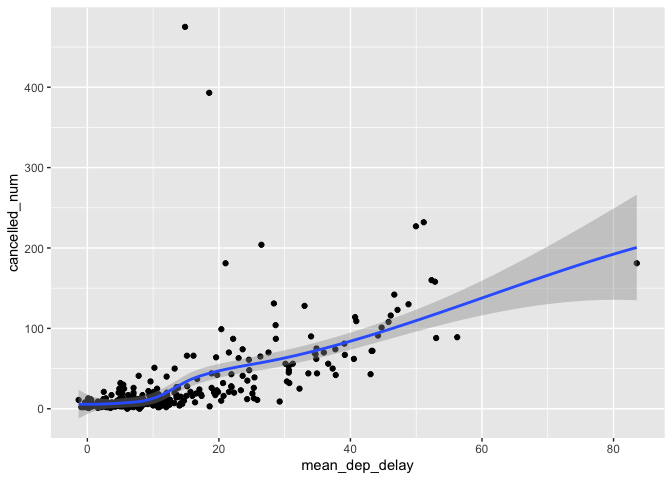

```r
#More concise and usable work
#cancelled and delay info must be in the same tibble / data frame

to_plot <- flights %>%
  mutate(cancelled=is.na(arr_delay)) %>%
  group_by(year,month,day) %>% #needed so we compare only flights per day
  summarise(cancelled_num = sum(cancelled),
            flights_tot = sum(year)/2013,
            mean_dep_delay = mean(dep_delay,na.rm=TRUE))

ggplot(to_plot, mapping = aes(x=mean_dep_delay,y=cancelled_num))+
  geom_point()+#mapping=aes(x=mean_dep_delay,y=cancelled_num,size=flights_tot))+
  geom_smooth()
```

The plot shows that there is a positive relationship between average departure delay and cancelled flights on any one day

Further analysis facet by month and think of weather as stated by the hints. x = day

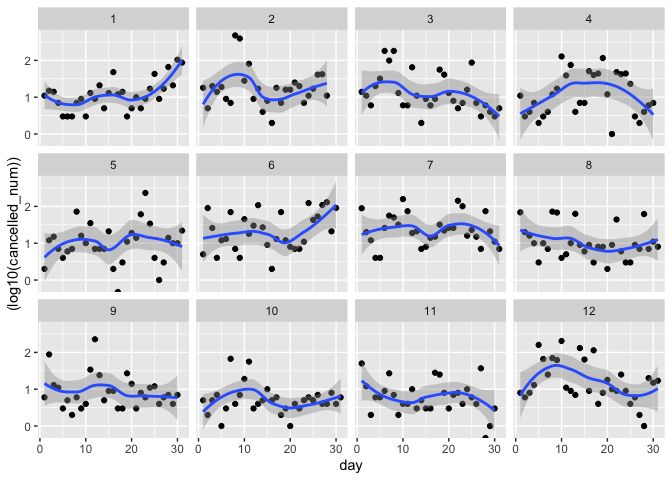

```r
ggplot(to_plot, mapping = aes(x=day,y=(log10(cancelled_num))))+
  geom_point()+
  geom_smooth()+
  facet_wrap(vars(month),ncol=4)
```

As given as a hint, log scales were experimented with along with faceting by month. This makes it seem that more cancellations happen in the winter and midsummer. This can make sense because weather can be the most inclement during these times.

### Exercise 5

Which carrier has the worst delays? Challenge: can you disentangle the effects of bad airports vs. bad carriers? Why/why not? (Hint: think about flights %>% group_by(carrier, dest) %>% summarise(n()))

Challenge: from the following data frame given in the question, it seems that the carrier and destination were able to be disentangled. However, it also seems that the dataset now has low numbers of flights for some combinations of carrier and destination. This does not promote accurate analysis of each combination due to low sample size.

```r
disentangled  <- not_cancelled %>%
  group_by(carrier,dest) %>%
  summarise(n())

disentangled
```

```
## # A tibble: 312 × 3
## # Groups:   carrier [16]
##    carrier dest  `n()`
##    <chr>   <chr> <int>
##  1 9E      ATL      56
##  2 9E      AUS       2
##  3 9E      AVL      10
##  4 9E      BNA     452
##  5 9E      BOS     853
##  6 9E      BTV       2
##  7 9E      BUF     789
##  8 9E      BWI     815
##  9 9E      CAE       3
## 10 9E      CHS     331
## # … with 302 more rows
```

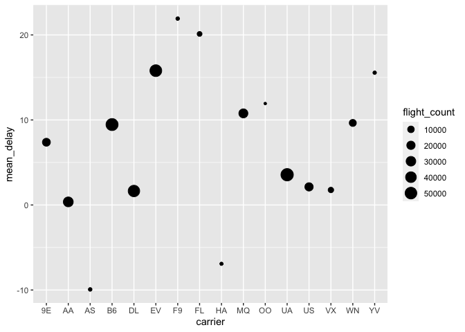

```r
to_plot <- not_cancelled %>%
  group_by(carrier) %>%
  summarise(mean_delay = mean(arr_delay),flight_count = n())

ggplot(to_plot,mapping=aes(x=carrier,y=mean_delay))+
  geom_point(mapping=aes(x=carrier,y=mean_delay,size=flight_count))
```

From this plot, the mean delays of each airline can be seen, along with the number of flights that airline offers. EV is one of the worst at a larger sample size

### Exercise 6

What does the sort argument to count() do. When might you use it?

Tests

```r
count(not_cancelled,carrier)
```

```
## # A tibble: 16 × 2
##    carrier     n
##    <chr>   <int>
##  1 9E      17294
##  2 AA      31947
##  3 AS        709
##  4 B6      54049
##  5 DL      47658
##  6 EV      51108
##  7 F9        681
##  8 FL       3175
##  9 HA        342
## 10 MQ      25037
## 11 OO         29
## 12 UA      57782
## 13 US      19831
## 14 VX       5116
## 15 WN      12044
## 16 YV        544
```

```r
#above is the same as

not_cancelled %>% count(carrier) %>% arrange(desc(n))
```

```
## # A tibble: 16 × 2
##    carrier     n
##    <chr>   <int>
##  1 UA      57782
##  2 B6      54049
##  3 EV      51108
##  4 DL      47658
##  5 AA      31947
##  6 MQ      25037
##  7 US      19831
##  8 9E      17294
##  9 WN      12044
## 10 VX       5116
## 11 FL       3175
## 12 AS        709
## 13 F9        681
## 14 YV        544
## 15 HA        342
## 16 OO         29
```

```r
#it is seen that count will group by and then summarise, this was used earlier in the exercises as well.

#exploring what sort does
not_cancelled %>% count(carrier,sort=TRUE)
```

```
## # A tibble: 16 × 2
##    carrier     n
##    <chr>   <int>
##  1 UA      57782
##  2 B6      54049
##  3 EV      51108
##  4 DL      47658
##  5 AA      31947
##  6 MQ      25037
##  7 US      19831
##  8 9E      17294
##  9 WN      12044
## 10 VX       5116
## 11 FL       3175
## 12 AS        709
## 13 F9        681
## 14 YV        544
## 15 HA        342
## 16 OO         29
```

```r
#the sort functions just as the arrange, its default is false
```

## 5.7.1 (1-5) & (7-8)

Hints: + for exercise 5, group and arrange the rows of flights such that consecutive rows are comparable so that lag() can be used. + for example, youll only want to compare flights from the same airport on the same day, then make a scatterplot of the flight delay vs the delay of the flight immediately afer

For the “challenge” part of R4DS 5.6.7 Exercise 5, think about how the you could explore if the destinations flow by carriers is different. For example, does the “worst” carrier fly to just a few destinations? Do other carriers also perform similarly with those destinations? Are there “worst” destinations in terms of delays? You can make a plot or a few summaries to begin this exploration, but you do not need to come up with a definitive answer. What’s important is understanding that there is a potential effect of the destination and also an interaction between the destination and carrier.

For R4DS 5.7.1 Exercise 1, you can refer to R4DS 5.5.1 (Useful creation functions) and ignore the list of useful filtering functions (there doesn’t seem to be any such list in R4DS). The important concept of this exercise is to think about how the unit analysis changes from the entire data frame to individual groups when you use group_by().

### Exercise 1

describe how each mutate and filter function operation changes when combined with grouping

Mutate Usually adds new variables and preserves existing ones

Filter with rank function ranking will now find the worst or best (depending on desc() or not) in each group

Filter with n() all groups following an equality statement will now be filtered such as n() > 10 will yield all groups with 10 or more entries

mutate after grouping compute per group metrics

### Exercise 2

which plane has the worst on-time record (tailnum)

```r
worst_flights <- not_cancelled %>%
  group_by(tailnum) %>%
  summarise(num_flights=n(),mean_delay=mean(arr_delay)) %>%
  arrange(desc(mean_delay)) %>%
  filter(num_flights>=20)

worst_flights
```

```
## # A tibble: 3,146 × 3
##    tailnum num_flights mean_delay
##    <chr>         <int>      <dbl>
##  1 N203FR           41       59.1
##  2 N645MQ           24       51
##  3 N956AT           34       47.6
##  4 N988AT           35       44.3
##  5 N521VA           27       42.2
##  6 N353AT           21       41.2
##  7 N942AT           20       41.2
##  8 N6716C           25       40.3
##  9 N908MQ           21       38.5
## 10 N657MQ           36       38.5
## # … with 3,136 more rows
```

The single worst delay was from plane N844MH, but this only has one flight. It is more appropriate to consider only flights with significant history, say 20 or more flights. Using this, the worst average arrival delay comes from plane N203FR.

### Exercise 3

What time of day is the best to fly if you want to avoid delays?

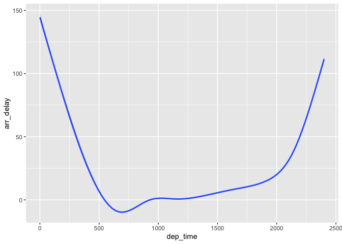

```r
#best_time_to_fly <- flights %>%


#rudimentary inspection
ggplot(flights,mapping=aes(x=dep_time,y=arr_delay))+
  geom_smooth()
```

```r
#there are many points here. so the smooth geom works the best.
#this indicates that a departure time between 500 and 1000 works best.
#these correspond to local time zones of between 5am and 10am
#the ends of the plot could be misleading, a graphical approach may not be optimal. Sorting the dataset by hour may be better

#Sorting by hour
best_time_to_fly <- not_cancelled %>%
  group_by(hour) %>%
  summarise(mean_delay=mean(arr_delay)) %>%
  arrange((mean_delay))


best_time_to_fly
```

```
## # A tibble: 19 × 2
##     hour mean_delay
##    <dbl>      <dbl>
##  1     7     -5.30
##  2     5     -4.80
##  3     6     -3.38
##  4     9     -1.45
##  5     8     -1.11
##  6    10      0.954
##  7    11      1.48
##  8    12      3.49
##  9    13      6.54
## 10    14      9.20
## 11    23     11.8
## 12    15     12.3
## 13    16     12.6
## 14    18     14.8
## 15    22     16.0
## 16    17     16.0
## 17    19     16.7
## 18    20     16.7
## 19    21     18.4
```

```r
#This approach also shows that leaving early, between 5am and 10am is the best time to leave. Interestingly, there are no flights leaving between 1am and 4 am in local time, agreeing with the plot
```

answer is commented

### Exercise 4

for each destination, compute the total minutes of delay. for each flight, compute the proportion of the total delay for its destination

```r
#part 1
delay <- not_cancelled %>%
  group_by(dest) %>%
  mutate(total_delay_for_dest = sum(arr_delay)) %>%
  arrange(dest) #to check it was done correctly

delay
```

```
## # A tibble: 327,346 × 20
## # Groups:   dest [104]
##     year month   day dep_time sched_dep_time dep_delay arr_time sched_arr_time
##    <int> <int> <int>    <int>          <int>     <dbl>    <int>          <int>
##  1  2013    10     1     1955           2001        -6     2213           2248
##  2  2013    10     2     2010           2001         9     2230           2248
##  3  2013    10     3     1955           2001        -6     2232           2248
##  4  2013    10     4     2017           2001        16     2304           2248
##  5  2013    10     5     1959           1959         0     2226           2246
##  6  2013    10     6     1959           2001        -2     2234           2248
##  7  2013    10     7     2002           2001         1     2233           2248
##  8  2013    10     8     1957           2001        -4     2216           2248
##  9  2013    10     9     1957           2001        -4     2220           2248
## 10  2013    10    10     2011           2001        10     2235           2248
## # … with 327,336 more rows, and 12 more variables: arr_delay <dbl>,
## #   carrier <chr>, flight <int>, tailnum <chr>, origin <chr>, dest <chr>,
## #   air_time <dbl>, distance <dbl>, hour <dbl>, minute <dbl>, time_hour <dttm>,
## #   total_delay_for_dest <dbl>
```

```r
#ungroup
#unsumarise but keep the data?

#delay per flight proportionally by destination
delay_prop <- delay %>%
  ungroup() %>%
  mutate(proportion_of_delay = arr_delay/total_delay_for_dest)

delay_prop
```

```
## # A tibble: 327,346 × 21
##     year month   day dep_time sched_dep_time dep_delay arr_time sched_arr_time
##    <int> <int> <int>    <int>          <int>     <dbl>    <int>          <int>
##  1  2013    10     1     1955           2001        -6     2213           2248
##  2  2013    10     2     2010           2001         9     2230           2248
##  3  2013    10     3     1955           2001        -6     2232           2248
##  4  2013    10     4     2017           2001        16     2304           2248
##  5  2013    10     5     1959           1959         0     2226           2246
##  6  2013    10     6     1959           2001        -2     2234           2248
##  7  2013    10     7     2002           2001         1     2233           2248
##  8  2013    10     8     1957           2001        -4     2216           2248
##  9  2013    10     9     1957           2001        -4     2220           2248
## 10  2013    10    10     2011           2001        10     2235           2248
## # … with 327,336 more rows, and 13 more variables: arr_delay <dbl>,
## #   carrier <chr>, flight <int>, tailnum <chr>, origin <chr>, dest <chr>,
## #   air_time <dbl>, distance <dbl>, hour <dbl>, minute <dbl>, time_hour <dttm>,
## #   total_delay_for_dest <dbl>, proportion_of_delay <dbl>
```

comment: good use of ungroup!

### Exercise 5

hints available

methodology: x axis: delay of previous flight, use lag() y axis: delay of current flight

```r
to_plot <- not_cancelled %>%
  group_by(origin) %>%
  arrange(origin,year,month,day,hour,minute,dep_time) %>%
  mutate(previous_delay = lag(arr_delay)) %>%
  select(day,dep_time,origin,previous_delay,arr_delay,everything())
#select lets me see that I operated as intended

to_plot
```

```
## # A tibble: 327,346 × 20
## # Groups:   origin [3]
##      day dep_time origin previous_delay arr_delay  year month sched_dep_time
##    <int>    <int> <chr>           <dbl>     <dbl> <int> <int>          <int>
##  1     1      517 EWR                NA        11  2013     1            515
##  2     1      554 EWR                11        12  2013     1            558
##  3     1      555 EWR                12        19  2013     1            600
##  4     1      558 EWR                19       -14  2013     1            600
##  5     1      559 EWR               -14        -8  2013     1            600
##  6     1      601 EWR                -8        -6  2013     1            600
##  7     1      608 EWR                -6        32  2013     1            600
##  8     1      607 EWR                32       -17  2013     1            607
##  9     1      632 EWR               -17        12  2013     1            608
## 10     1      606 EWR                12       -12  2013     1            610
## # … with 327,336 more rows, and 12 more variables: dep_delay <dbl>,
## #   arr_time <int>, sched_arr_time <int>, carrier <chr>, flight <int>,
## #   tailnum <chr>, dest <chr>, air_time <dbl>, distance <dbl>, hour <dbl>,
## #   minute <dbl>, time_hour <dttm>
```

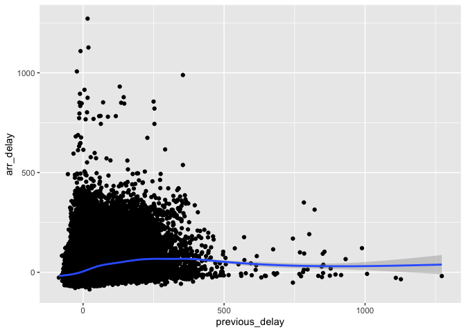

```r
ggplot(to_plot,mapping=aes(x=previous_delay,y=arr_delay)) +
  geom_point()+
  geom_smooth()
```

This is the relation I found

### Exercise 7 (skip 6)

find all the destinations that are serviced by at least two carriers. use this info to rank the carriers

```r
two_dest <- not_cancelled %>%
  arrange(dest) %>%
  select(dest,carrier,everything()) %>%
  group_by(dest,carrier) %>%
  count(dest) %>%
  ungroup() %>%
  filter(dest==lead(dest) | dest==lag(dest))
  #select(carrier,dest,everything())

  two_dest
```

```
## # A tibble: 283 × 3
##    dest  carrier     n
##    <chr> <chr>   <int>
##  1 ATL   9E         56
##  2 ATL   DL      10452
##  3 ATL   EV       1656
##  4 ATL   FL       2278
##  5 ATL   MQ       2235
##  6 ATL   UA        102
##  7 ATL   WN         58
##  8 AUS   9E          2
##  9 AUS   AA        358
## 10 AUS   B6        742
## # … with 273 more rows
```

```r
#this tibble contains only destinations that are flown by at least two carriers, more specifically, there is a row for each destination carrier combination, with a number of flights that the combination hosted.

#now to rank the carriers

ranked <- two_dest %>%
  count(carrier) %>%
  arrange(n) %>%
  select(carrier,num_destinations_serviced=n)

ranked
```

```
## # A tibble: 16 × 2
##    carrier num_destinations_serviced
##    <chr>                       <int>
##  1 AS                              1
##  2 F9                              1
##  3 HA                              1
##  4 FL                              2
##  5 YV                              3
##  6 VX                              4
##  7 OO                              5
##  8 US                              5
##  9 WN                             10
## 10 AA                             19
## 11 MQ                             19
## 12 B6                             35
## 13 DL                             39
## 14 UA                             42
## 15 9E                             47
## 16 EV                             50
```

```r
#now that I think of it, I could have done a second count on destination to get the same answer in a more concise manner for part 1. Doing this below

two_dest_improved <- not_cancelled %>%
  arrange(dest) %>%
  select(dest,carrier,everything()) %>%
  group_by(dest,carrier) %>%
  count(dest) %>%
  ungroup() %>%
  count(dest) %>%
  arrange(n) %>%
  select(dest,carriers_servicing=n) %>%
  filter(carriers_servicing>1)

two_dest_improved
```

```
## # A tibble: 75 × 2
##    dest  carriers_servicing
##    <chr>              <int>
##  1 AVL                    2
##  2 BDL                    2
##  3 BQN                    2
##  4 CAE                    2
##  5 DAY                    2
##  6 DSM                    2
##  7 EGE                    2
##  8 GRR                    2
##  9 GSO                    2
## 10 GSP                    2
## # … with 65 more rows
```

### Exercise 8

for each plane, count the # of flights before the first delay of greater than 1 hour

```r
delay_1h <- not_cancelled %>%
  group_by(tailnum) %>%
  arrange(year,month,day,hour,minute) %>%
  select(month,day,hour,minute,dep_delay,everything()) %>%
  mutate(metric = dep_delay<=60) %>%
  mutate(flight_count = metric+sum(lag(metric),na.rm=T)) %>%
  select(day,hour,minute,dep_delay,metric,tailnum,flight_count,everything())


delay_1h
```

```
## # A tibble: 327,346 × 21
## # Groups:   tailnum [4,037]
##      day  hour minute dep_delay metric tailnum flight_count month  year dep_time
##    <int> <dbl>  <dbl>     <dbl> <lgl>  <chr>          <int> <int> <int>    <int>
##  1     1     5     15         2 TRUE   N14228           104     1  2013      517
##  2     1     5     29         4 TRUE   N24211           121     1  2013      533
##  3     1     5     40         2 TRUE   N619AA            22     1  2013      542
##  4     1     5     45        -1 TRUE   N804JB           205     1  2013      544
##  5     1     5     58        -4 TRUE   N39463           102     1  2013      554
##  6     1     5     59         0 TRUE   N708JB           221     1  2013      559
##  7     1     6      0        -6 TRUE   N668DN            45     1  2013      554
##  8     1     6      0        -5 TRUE   N516JB           264     1  2013      555
##  9     1     6      0        -3 TRUE   N829AS           183     1  2013      557
## 10     1     6      0        -3 TRUE   N593JB           263     1  2013      557
## # … with 327,336 more rows, and 11 more variables: sched_dep_time <int>,
## #   arr_time <int>, sched_arr_time <int>, arr_delay <dbl>, carrier <chr>,
## #   flight <int>, origin <chr>, dest <chr>, air_time <dbl>, distance <dbl>,
## #   time_hour <dttm>
```

```r
#this approach proved not to work well

try2 <- not_cancelled %>%
  group_by(tailnum,month,day,hour,minute) %>%
  arrange(tailnum,month,day,hour,minute,.bygroup=TRUE) %>%
  mutate(on_time = dep_delay<60) %>%
  select(tailnum,month,day,hour,minute,on_time,dep_delay,everything()) %>%
  ungroup() %>%
  group_by(tailnum) %>%
  mutate(flight_count=cumsum(on_time)) %>%
  select(flight_count,tailnum,hour,minute,on_time,dep_delay,everything()) %>%
  filter(on_time==FALSE) %>%
  filter(flight_count==min(flight_count))


try2
```

```
## # A tibble: 3,881 × 21
## # Groups:   tailnum [3,368]
##    flight_count tailnum  hour minute on_time dep_delay month   day  year
##           <int> <chr>   <dbl>  <dbl> <lgl>       <dbl> <int> <int> <int>
##  1            0 D942DN     14      0 FALSE          68     2    11  2013
##  2           53 N0EGMQ     10     50 FALSE          80     2     8  2013
##  3           53 N0EGMQ     19     40 FALSE         138     2    11  2013
##  4            9 N10156     20     39 FALSE         102     1    13  2013
##  5           25 N102UW     17      5 FALSE         276     6    22  2013
##  6            3 N104UW     12      0 FALSE          91     2    13  2013
##  7            0 N10575     13     40 FALSE         128     1     2  2013
##  8           22 N105UW     12      0 FALSE         131     7    11  2013
##  9           20 N107US     15      0 FALSE          84     7    27  2013
## 10           36 N108UW     12      0 FALSE          89     8    13  2013
## # … with 3,871 more rows, and 12 more variables: dep_time <int>,
## #   sched_dep_time <int>, arr_time <int>, sched_arr_time <int>,
## #   arr_delay <dbl>, carrier <chr>, flight <int>, origin <chr>, dest <chr>,
## #   air_time <dbl>, distance <dbl>, time_hour <dttm>
```

```r
#this approach will have two rows for a tailnum if there are two late flights in a row for that plane.
```

## Additional Exercises (3)

### Exercise 1

make a plot showing the median dep delay by month. along with a shaded region indicating the lower and upper quartiles like the one given.

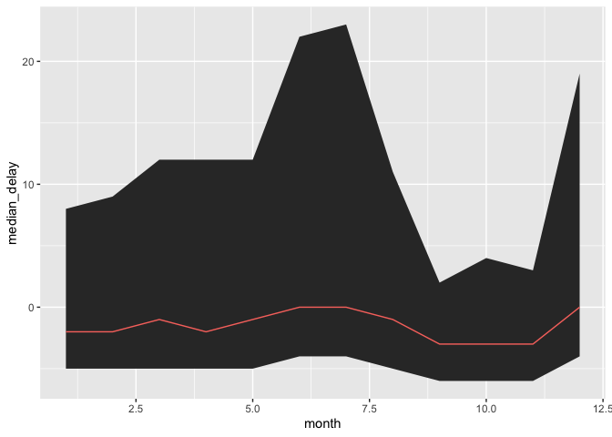

```r
newnot_cancelled <- not_cancelled %>%
  group_by(month) %>%
  summarise(median_delay=median(dep_delay),q1=quantile(dep_delay,0.25),q3=quantile(dep_delay,0.75))
  #mutate(dep_delaymed=median(dep_delay)) %>%
  #select(month,dep_delaymed,everything())

ggplot(newnot_cancelled,mapping=aes(x=month,y=median_delay))+
  geom_ribbon(aes(ymin=newnot_cancelled$q1,ymax=newnot_cancelled$q3)) +
  geom_line(aes(color="blue"),show.legend = F)
```

```r
not_cancelled
```

```
## # A tibble: 327,346 × 19
##     year month   day dep_time sched_dep_time dep_delay arr_time sched_arr_time
##    <int> <int> <int>    <int>          <int>     <dbl>    <int>          <int>
##  1  2013     1     1      517            515         2      830            819
##  2  2013     1     1      533            529         4      850            830
##  3  2013     1     1      542            540         2      923            850
##  4  2013     1     1      544            545        -1     1004           1022
##  5  2013     1     1      554            600        -6      812            837
##  6  2013     1     1      554            558        -4      740            728
##  7  2013     1     1      555            600        -5      913            854
##  8  2013     1     1      557            600        -3      709            723
##  9  2013     1     1      557            600        -3      838            846
## 10  2013     1     1      558            600        -2      753            745
## # … with 327,336 more rows, and 11 more variables: arr_delay <dbl>,
## #   carrier <chr>, flight <int>, tailnum <chr>, origin <chr>, dest <chr>,
## #   air_time <dbl>, distance <dbl>, hour <dbl>, minute <dbl>, time_hour <dttm>
```

### Exercise 2

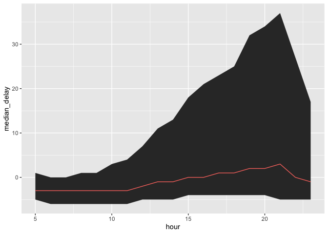

```r
newnot_cancelled2 <- not_cancelled %>%
  group_by(hour) %>%
  summarise(median_delay=median(dep_delay),q1=quantile(dep_delay,0.25),q3=quantile(dep_delay,0.75))
  #mutate(dep_delaymed=median(dep_delay)) %>%
  #select(month,dep_delaymed,everything())

ggplot(newnot_cancelled2,mapping=aes(x=hour,y=median_delay))+
  geom_ribbon(aes(ymin=newnot_cancelled2$q1,ymax=newnot_cancelled2$q3)) +
  geom_line(aes(color="blue"),show.legend = F)
```

```r
not_cancelled
```

```
## # A tibble: 327,346 × 19
##     year month   day dep_time sched_dep_time dep_delay arr_time sched_arr_time
##    <int> <int> <int>    <int>          <int>     <dbl>    <int>          <int>
##  1  2013     1     1      517            515         2      830            819
##  2  2013     1     1      533            529         4      850            830
##  3  2013     1     1      542            540         2      923            850
##  4  2013     1     1      544            545        -1     1004           1022
##  5  2013     1     1      554            600        -6      812            837
##  6  2013     1     1      554            558        -4      740            728
##  7  2013     1     1      555            600        -5      913            854
##  8  2013     1     1      557            600        -3      709            723
##  9  2013     1     1      557            600        -3      838            846
## 10  2013     1     1      558            600        -2      753            745
## # … with 327,336 more rows, and 11 more variables: arr_delay <dbl>,
## #   carrier <chr>, flight <int>, tailnum <chr>, origin <chr>, dest <chr>,
## #   air_time <dbl>, distance <dbl>, hour <dbl>, minute <dbl>, time_hour <dttm>
```

### Exercise 3

top 5 destinations per month top 5 dest per year use total flight #

```r
top_dest <- not_cancelled %>%
  group_by(month,dest) %>%
  summarise(n=n()) %>%
  arrange(month,desc(n),by_group=T) %>%
  mutate(rank=rank(desc(n))) %>%
  filter(rank<=5) %>%
  ungroup() #%>%
  #count(dest)

top_dest
```

```
## # A tibble: 60 × 4
##    month dest      n  rank
##    <int> <chr> <int> <dbl>
##  1     1 ATL    1368     1
##  2     1 ORD    1227     2
##  3     1 BOS    1214     3
##  4     1 MCO    1173     4
##  5     1 FLL    1155     5
##  6     2 ATL    1212     1
##  7     2 ORD    1109     2
##  8     2 BOS    1100     3
##  9     2 MCO    1069     4
## 10     2 FLL    1033     5
## # … with 50 more rows
```

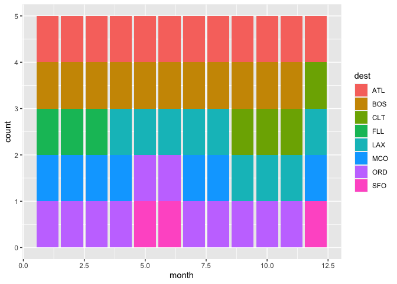

```r
ggplot(data=top_dest) +
  geom_bar(mapping=aes(x=month,fill=dest))#,position="dodge")
```

The plot shows that the most popular destinations do change with the month, with some that stay year round. This may be because of weather patterns that make certain destinations best at a certain time of year. The bars show the 5 top destinations for each month.

now to get the top 5 destinations for the year

```r
top_dest <- not_cancelled %>%
  group_by(dest) %>%
  summarise(n=n()) %>%
  arrange(desc(n),by_group=T) %>%
  mutate(rank=rank(desc(n))) %>%
  filter(rank<=5) %>%
  ungroup() #%>%
  #count(dest)

top_dest
```

```
## # A tibble: 5 × 3
##   dest      n  rank
##   <chr> <int> <dbl>
## 1 ATL   16837     1
## 2 ORD   16566     2
## 3 LAX   16026     3
## 4 BOS   15022     4
## 5 MCO   13967     5
```

## Discussion for module 5

```r
columbus_flights <- not_cancelled %>%
  filter(arr_delay<0) %>%
  group_by(dest) %>%
  summarise(number=n()) %>%
  arrange()

columbus_flights
```

```
## # A tibble: 104 × 2
##    dest  number
##    <chr>  <int>
##  1 ABQ      145
##  2 ACK      155
##  3 ALB      229
##  4 ANC        3
##  5 ATL     8541
##  6 AUS     1401
##  7 AVL      134
##  8 BDL      264
##  9 BGR      216
## 10 BHM      144
## # … with 94 more rows
```

```r
#Page 3 has Columbus (CMH) at a count of 1842 early flights
```